# Run Rate Analyses Post Lockdown

### FDM

- Train Data 6 January 2020 to 22 March 2020
- Test Data 27 July 2020 to 4 October 2020

#### Independent variables

**Time**

- Day of week

**Engineering**

- Number of LHDs Loading

**Ore Availability**

- Rings Blasted Block 5SLC 70L sum of 7 days lagging window
- Rings Blasted Block 5SLC 73L sum of 7 days lagging window
- Rings Blasted Block 5SLC 75L sum of 7 days lagging window
- Rings Blasted Block 5SLC 78L sum of 7 days lagging window

**Area Contribution**

- Hoisted Block 5 SLC 70L loading fraction
- Hoisted Block 5 SLC 73L loading fraction
- Hoisted Block 5 SLC 75L loading fraction
- Hoisted Block 5 SLC 78L loading fraction
- Hoisted Block 5 SLC Phase 2 73L loading fraction
- Hoisted Block 5 SLC Phase 2 73L loading fraction

#### Dependent variable

- Daily Tonnes Hoisted

```r
# Read train data and inspect
FDMTrainCSV <- read.csv("~/GitHub/PMO/Dataset/FDMTrain.csv")
str(FDMTrainCSV)
```

```
## 'data.frame':    76 obs. of  14 variables:
##  $ Instant                        : int  1 2 3 4 5 6 7 8 9 10 ...
##  $ Weekday                        : int  1 2 3 4 5 6 7 1 2 3 ...
##  $ Rings.Blasted.Block.5.SLC.70L  : int  4 4 4 1 2 3 3 2 2 2 ...
##  $ Rings.Blasted.Block.5.SLC.73L  : int  6 8 9 5 5 5 5 5 3 2 ...
##  $ Rings.Blasted.Block.5.SLC.75L  : int  1 2 2 1 2 2 3 3 3 3 ...
##  $ Rings.Blasted.Block.5.SLC.78L  : int  0 0 0 0 0 0 0 0 0 0 ...
##  $ Hoisted.BLOCK.5.SLC.70L        : num  0 0 0 0.0715 0 ...
##  $ Hoisted.BLOCK.5.SLC.73L        : num  0.403 0.267 0.329 0.265 0.536 ...
##  $ Hoisted.BLOCK.5.SLC.75L        : num  0.232 0.307 0.337 0.296 0.203 ...
##  $ Hoisted.BLOCK.5.SLC.78L        : num  0.0206 0.0324 0.0825 0 0.1747 ...
##  $ Hoisted.BLOCK.5.SLC.Phase.2.70L: num  0.1142 0.2456 0.1678 0.209 0.0183 ...
##  $ Hoisted.BLOCK.5.SLC.Phase.2.73L: num  0.2302 0.1477 0.0839 0.1589 0.0676 ...
##  $ Distinct.LHDs                  : int  12 11 13 12 10 11 10 13 10 11 ...
##  $ DailyHoist                     : num  7865 9747 9998 10736 6057 ...
```

```r
summary(FDMTrainCSV)
```

```
##     Instant         Weekday      Rings.Blasted.Block.5.SLC.70L
##  Min.   : 1.00   Min.   :1.000   Min.   :0.000
##  1st Qu.:19.75   1st Qu.:2.000   1st Qu.:1.000
##  Median :38.50   Median :4.000   Median :2.000
##  Mean   :38.50   Mean   :3.961   Mean   :1.961
##  3rd Qu.:57.25   3rd Qu.:6.000   3rd Qu.:3.000
##  Max.   :76.00   Max.   :7.000   Max.   :4.000
##  Rings.Blasted.Block.5.SLC.73L Rings.Blasted.Block.5.SLC.75L
##  Min.   :1.000                 Min.   :0.00
##  1st Qu.:3.000                 1st Qu.:1.00
##  Median :4.000                 Median :2.00
##  Mean   :4.276                 Mean   :2.25
##  3rd Qu.:5.000                 3rd Qu.:3.00
##  Max.   :9.000                 Max.   :5.00
##  Rings.Blasted.Block.5.SLC.78L Hoisted.BLOCK.5.SLC.70L
##  Min.   :0.0000                Min.   :0.000000
##  1st Qu.:0.0000                1st Qu.:0.000000
##  Median :0.0000                Median :0.000000
##  Mean   :0.1447                Mean   :0.022325
##  3rd Qu.:0.0000                3rd Qu.:0.009904
##  Max.   :1.0000                Max.   :0.250414
##  Hoisted.BLOCK.5.SLC.73L Hoisted.BLOCK.5.SLC.75L Hoisted.BLOCK.5.SLC.78L
##  Min.   :0.0000          Min.   :0.0000          Min.   :0.00000
##  1st Qu.:0.1854          1st Qu.:0.3067          1st Qu.:0.00000
##  Median :0.2635          Median :0.3817          Median :0.00385
##  Mean   :0.2660          Mean   :0.3704          Mean   :0.04345
##  3rd Qu.:0.3253          3rd Qu.:0.4543          3rd Qu.:0.08240
##  Max.   :1.0000          Max.   :0.6086          Max.   :0.24215
##  Hoisted.BLOCK.5.SLC.Phase.2.70L Hoisted.BLOCK.5.SLC.Phase.2.73L
##  Min.   :0.0000000               Min.   :0.00000
##  1st Qu.:0.0009333               1st Qu.:0.09617
##  Median :0.1280244               Median :0.15542
##  Mean   :0.1316322               Mean   :0.15303
##  3rd Qu.:0.2229688               3rd Qu.:0.19416
##  Max.   :0.4802891               Max.   :0.37195
##  Distinct.LHDs     DailyHoist
##  Min.   : 0.00   Min.   :    0
##  1st Qu.: 9.00   1st Qu.: 6685
##  Median :11.00   Median : 8414
##  Mean   :10.24   Mean   : 8198
##  3rd Qu.:11.00   3rd Qu.:10041
##  Max.   :14.00   Max.   :12271
```

#### Decriptive statisitcs and visualisation

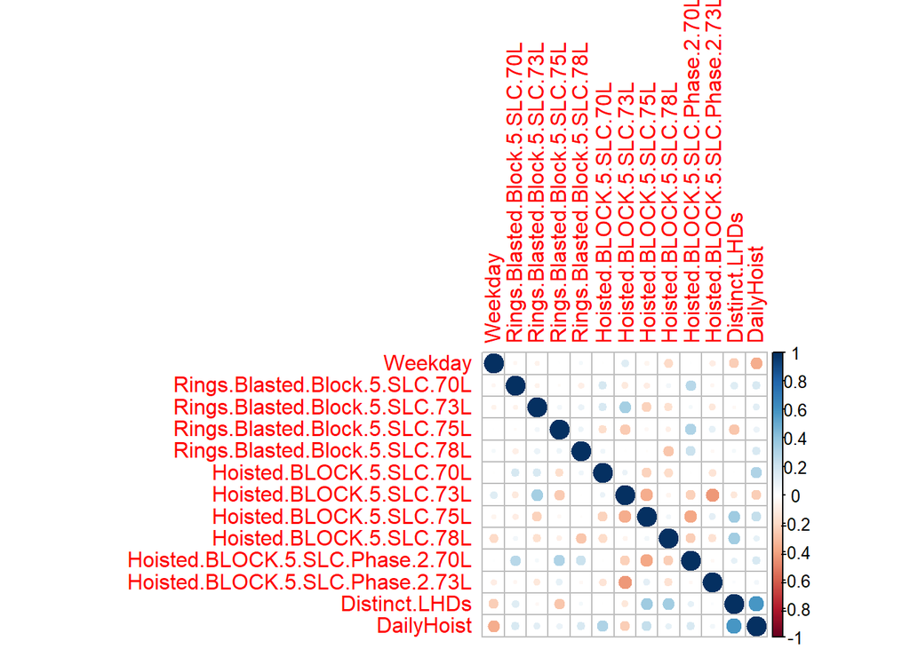

```r
# Understand correlation between variables
library(corrplot)
df<-as.matrix(FDMTrainCSV)
dfPairs <- df[,2:14]
dfPairs.cor<-cor(dfPairs)
corrplot(dfPairs.cor,method="circle")
```

```r
# Load required libraries
library(magrittr)
library(dplyr)
```

```r
library(ggplot2)
```

#### Compare algorithms for fit on Train and Test data

```r
mean(FDMTrainCSV$DailyHoist)
```

```
## [1] 8197.59
```

```r
var(FDMTrainCSV$DailyHoist)
```

```
## [1] 7058825
```

var >> mean

Will therefore use Quasipoisson and not Poisson

Models:

- Model1 = Quasipoisson
- Model2 = Random forest
- Model3 - XGBoost

```r
# Load Test data
FDMTestCSV <- read.csv("~/GitHub/PMO/Dataset/FDMTest.csv")
```

**Model quasipoisson**

```r
# Model quasipoisson
formula <- FDMTrainCSV$DailyHoist~.-Instant
model1 <- glm(formula,data=FDMTrainCSV,family=quasipoisson)
# Predict on test data
pred1<-predict(model1,newdata=FDMTestCSV,type="response")
summary(pred1)
```

```
##    Min. 1st Qu.  Median    Mean 3rd Qu.    Max.
##       0    5610    6823    6986    7797   15626
```

```r
# Calculate RMSE
FDMTestCSV %>%
mutate(residual = pred1 - DailyHoist) %>%
summarise(rmse=sqrt(mean(residual^2)))
```

| rmse |
| --- |
| 3116.759 |

**Model random forest**

```r
# Model random forest
library(ranger)
set.seed(5)
formula <- FDMTrainCSV$DailyHoist~.-Instant
model2 <- ranger(formula,FDMTrainCSV,num.trees=500,respect.unordered.factors = "order")
# Predict on test data
FDMTestCSV$pred2 <- predict(model2,FDMTestCSV)$predictions
summary(FDMTestCSV$pred2)
```

```
##    Min. 1st Qu.  Median    Mean 3rd Qu.    Max.
##    3040    6901    7421    7245    8129    9209
```

```r
# Calculate RMSE
FDMTestCSV %>%
mutate(residual = pred2 - DailyHoist) %>%
summarise(rmse=sqrt(mean(residual^2)))
```

| rmse |
| --- |
| 2462.104 |

**Model XGBoost**

```r
# Model XGBoost
library(xgboost)
library(vtreat)
set.seed(1)
(outcome <- "DailyHoist")
```

```
## [1] "DailyHoist"
```

```r
(vars <- c("Weekday", "Rings.Blasted.Block.5.SLC.70L","Rings.Blasted.Block.5.SLC.73L","Rings.Blasted.Block.5.SLC.75L","Rings.Blasted.Block.5.SLC.78L","Hoisted.BLOCK.5.SLC.70L","Hoisted.BLOCK.5.SLC.73L","Hoisted.BLOCK.5.SLC.75L","Hoisted.BLOCK.5.SLC.78L","Hoisted.BLOCK.5.Phase.2.SLC.70L","Hoisted.BLOCK.5.Phase.2.SLC.73L","Distinct.LHDs" ))
```

```
##  [1] "Weekday"                         "Rings.Blasted.Block.5.SLC.70L"
##  [3] "Rings.Blasted.Block.5.SLC.73L"   "Rings.Blasted.Block.5.SLC.75L"
##  [5] "Rings.Blasted.Block.5.SLC.78L"   "Hoisted.BLOCK.5.SLC.70L"
##  [7] "Hoisted.BLOCK.5.SLC.73L"         "Hoisted.BLOCK.5.SLC.75L"
##  [9] "Hoisted.BLOCK.5.SLC.78L"         "Hoisted.BLOCK.5.Phase.2.SLC.70L"
## [11] "Hoisted.BLOCK.5.Phase.2.SLC.73L" "Distinct.LHDs"
```

```r
treatplan <- designTreatmentsZ(FDMTrainCSV,vars,verbose = FALSE)
# Get the "clean" and "lev" variables from the scoreFrame
(newvars <- treatplan %>%
use_series(scoreFrame) %>%
filter(code %in% c("clean","lev")) %>%
use_series(varName))
```

```
##  [1] "Weekday"                       "Rings.Blasted.Block.5.SLC.70L"
##  [3] "Rings.Blasted.Block.5.SLC.73L" "Rings.Blasted.Block.5.SLC.75L"
##  [5] "Rings.Blasted.Block.5.SLC.78L" "Hoisted.BLOCK.5.SLC.70L"
##  [7] "Hoisted.BLOCK.5.SLC.73L"       "Hoisted.BLOCK.5.SLC.75L"
##  [9] "Hoisted.BLOCK.5.SLC.78L"       "Distinct.LHDs"
```

```r
# Prepare data  frames with new variables
FDMTrainCSV.treat <- prepare(treatplan,FDMTrainCSV, varRestriction = newvars)
FDMTestCSV.treat <- prepare(treatplan,FDMTestCSV, varRestriction = newvars)
#
cv <- xgb.cv(data = as.matrix(FDMTrainCSV.treat),
label = FDMTrainCSV$DailyHoist,
nrounds = 100,
nfold = 5,
objective = "reg:linear",
eta = 0.3,
max_depth = 6,
early_stopping_rounds = 10,
verbose = 0   # silent
)
# Get evaluation log
elog <- cv$evaluation_log
#Detrmine amount of trees minimising trees for train and test
elog %>%
summarize(ntrees.train = which.min(train_rmse_mean),   # find the index of min(train_rmse_mean)
ntrees.test  = which.min(test_rmse_mean))    # find the index of min(test_rmse_mean)
```

| ntrees.train | ntrees.test |
| --- | --- |
| 18 | 8 |

```r
#Use optimal tree

Hoist_model_xgb <- xgboost(data = as.matrix(FDMTrainCSV.treat), # training data as matrix
label = FDMTrainCSV$DailyHoist,  # column of outcomes
nrounds = 18,       # number of trees to build
objective = "reg:linear", # objective
eta = 0.3,
depth = 6,
verbose = 0  # silent
)
# Make predictions
FDMTestCSV$pred3 <- predict(Hoist_model_xgb,as.matrix(FDMTestCSV.treat))
# Calculate RMSE
FDMTestCSV %>%
mutate(residual = pred3 - DailyHoist) %>%
summarise(rmse=sqrt(mean(residual^2)))
```

| rmse |
| --- |
| 3024.121 |

**Random forest model yields the lowest RMSE and is selected**

#### Visualise prediction versus actuals for test data

model 2 selected

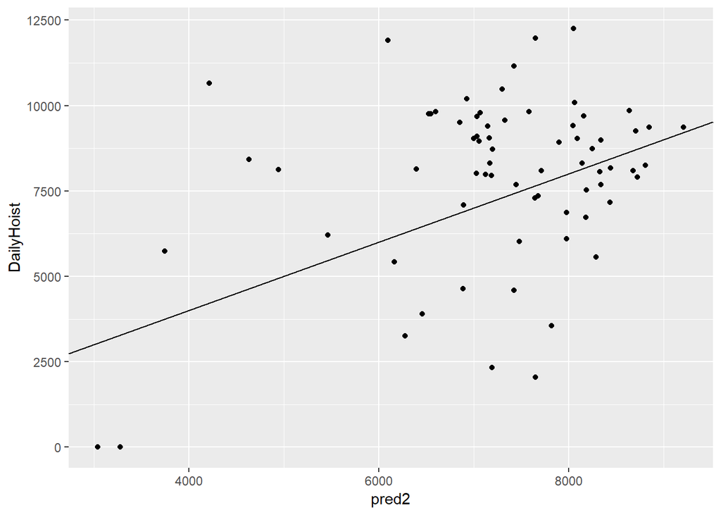

```r
#Plot prediction versus actual for test data
ggplot(FDMTestCSV, aes(x=pred2,y=DailyHoist))+
geom_point()+
geom_abline()
```

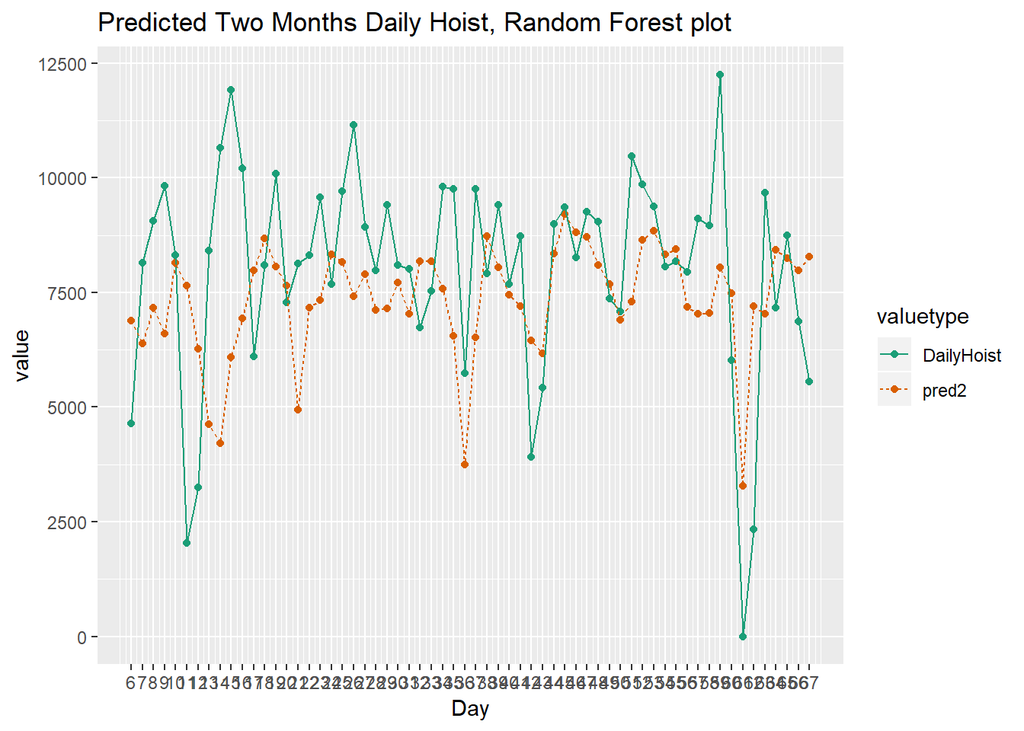

```r
#Plot prediction versus actual for test data example
library(tidyr)
# Week
AugAndSep <- FDMTestCSV %>%
  # Set start to 0
  mutate(Instant = (Instant - min(Instant))) %>%
  # Gather Buckets and pred2 into a column named value with key valuetype
  gather(key = valuetype, value = value, DailyHoist, pred2) %>%
  # Filter for rows
  filter(Instant <= 67 & Instant >= 6 )

# Plot predictions and Buckets by date/time
ggplot(AugAndSep, aes(x = Instant, y = value, color = valuetype, linetype = valuetype)) +
  geom_point() +
  geom_line() +
  scale_x_continuous("Day", breaks = 6:67, labels = 6:67) +
  scale_color_brewer(palette = "Dark2") +
  ggtitle("Predicted Two Months Daily Hoist, Random Forest plot")
```

```r
day_dif <- (FDMTestCSV)%>%
mutate(res = DailyHoist -pred2)     %>%
filter(Instant <= 67 & Instant > 6)
mapply(sum,day_dif[,14:15])
```

```
## DailyHoist      pred2
##   491755.0   446581.5
```

### Notes

#### Packages utilised

tidyr, caret, ranger, vtreat, xgboost, magrittr, ggplot2, dplyr, broom, knitr, rmarkdown, MultivariateRandomForest